# PCA Analysis - diamonds data set

Piotr Wieczorek

2023-07-18

# PCA Project - Reducing components of the diamonds data set to find characterstics for each price group

```r
library(readr)
library(tidyverse)
library(factoextra)
```

```r
df <- diamonds
```

```r
summary(df)
```

```
##      carat               cut        color        clarity          depth
##  Min.   :0.2000   Fair     : 1610   D: 6775   SI1    :13065   Min.   :43.00
##  1st Qu.:0.4000   Good     : 4906   E: 9797   VS2    :12258   1st Qu.:61.00
##  Median :0.7000   Very Good:12082   F: 9542   SI2    : 9194   Median :61.80
##  Mean   :0.7979   Premium  :13791   G:11292   VS1    : 8171   Mean   :61.75
##  3rd Qu.:1.0400   Ideal    :21551   H: 8304   VVS2   : 5066   3rd Qu.:62.50
##  Max.   :5.0100                     I: 5422   VVS1   : 3655   Max.   :79.00
##                                     J: 2808   (Other): 2531
##      table           price             x                y
##  Min.   :43.00   Min.   :  326   Min.   : 0.000   Min.   : 0.000
##  1st Qu.:56.00   1st Qu.:  950   1st Qu.: 4.710   1st Qu.: 4.720
##  Median :57.00   Median : 2401   Median : 5.700   Median : 5.710
##  Mean   :57.46   Mean   : 3933   Mean   : 5.731   Mean   : 5.735
##  3rd Qu.:59.00   3rd Qu.: 5324   3rd Qu.: 6.540   3rd Qu.: 6.540
##  Max.   :95.00   Max.   :18823   Max.   :10.740   Max.   :58.900
##
##        z
##  Min.   : 0.000
##  1st Qu.: 2.910
##  Median : 3.530
##  Mean   : 3.539
##  3rd Qu.: 4.040
##  Max.   :31.800
##
```

### Creating a column with price category based on the quantiles

```r
quantile(df$price,probs = seq(0.25,1,0.25))
```

```
##      25%      50%      75%     100%
##   950.00  2401.00  5324.25 18823.00
```

```r
df$price_category <- ifelse(df$price <= 950, "<=25%", ifelse(df$price <= 2401 & df$price >950, ">25% & <=50%",
                                                            ifelse(df$price <= 5324.25 & df$price > 2401, ">50% &<=75%",">75%")))
```

```r
df$price_category <- as.factor(df$price_category)
```

### Removing the price variable. Not removing it would make the PCA a lot biased, since we want to group the data based on the price category, and it would take some weight of price for the linear combination between PCA’s and the variables

```r
df <- df %>%
  select(-c("price"))
```

```r
df_numeric <- df[,c("carat","depth","table","x","y","z")]
```

```r
pca <- prcomp(df_numeric,scale. = TRUE)
```

### PCA1 and PCA2 together capture 86.94% of the overall variance.

```r
summary(pca)
```

```
## Importance of components:
##                           PC1    PC2    PC3    PC4     PC5    PC6
## Standard deviation     1.9830 1.1332 0.8267 0.2177 0.19950 0.1149
## Proportion of Variance 0.6554 0.2140 0.1139 0.0079 0.00663 0.0022
## Cumulative Proportion  0.6554 0.8694 0.9833 0.9912 0.99780 1.0000
```

### Eigen vectors - these are the weights for linear combinations between PCA’s and variables. For example: PC1 = 0.49carat + (-0.0006)depth + 0.12table … + 0.49z.

### PC1 puts mostly weight on carat, x, y and z, while PC2 puts mostly weight on depth and table.

```r
pca$rotation
```

```
##                 PC1          PC2          PC3         PC4          PC5
## carat  0.4953672774 -0.045129669  0.027908324 -0.78996536 -0.160214816
## depth -0.0006822439 -0.734082087 -0.671000723  0.01402986 -0.088358027
## table  0.1205813877  0.669826823 -0.732523408  0.01345637 -0.002961066
## x      0.5009101500 -0.008203685  0.069979239 -0.04075903  0.048631847
## y      0.4952175606 -0.009657367  0.086227223  0.53762228 -0.635139814
## z      0.4938820845 -0.101283089 -0.007508905  0.29133794  0.748830865
##                PC6
## carat -0.319502171
## depth  0.053638379
## table -0.003430812
## x      0.860289644
## y     -0.234074490
## z     -0.316449645
```

### Principal Component’s Scores:

### To get these numbers, the matrix of the scaled data is multiplied by the vector of ordered eigen vectors

```r
head(pca$x)
```

```
##            PC1         PC2        PC3         PC4         PC5         PC6
## [1,] -3.058053 -0.36772547  0.6571260 -0.28963012 -0.06742709 -0.13197943
## [2,] -2.925839  2.32271485 -0.5278078 -0.35007528 -0.01585099 -0.15487212
## [3,] -2.516531  5.00273834 -0.4523066 -0.28526662  0.02998189 -0.20750423
## [4,] -2.473886  0.03205256 -0.7120120 -0.17158042 -0.06315317 -0.09252400
## [5,] -2.254885 -0.45027707 -1.1158535 -0.09515818 -0.05874940 -0.04334452
## [6,] -2.918439 -0.44220342 -0.6094869 -0.26992953 -0.08989147 -0.11910888
```

### Scree plot

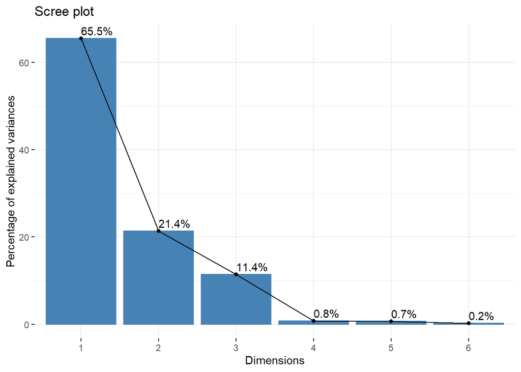

```r
fviz_eig(pca,addlabels = TRUE)
```

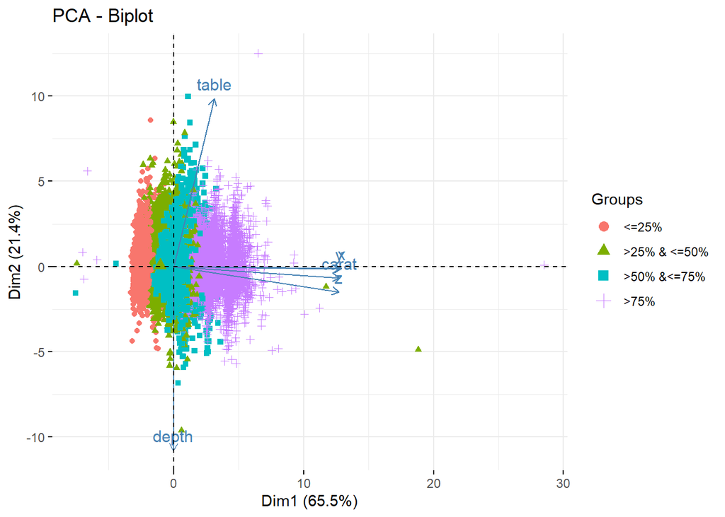

```r
fviz_pca_biplot(pca,label="var",
                habillage = df$price_category)
```

```r
pca$rotation
```

```
##                 PC1          PC2          PC3         PC4          PC5
## carat  0.4953672774 -0.045129669  0.027908324 -0.78996536 -0.160214816
## depth -0.0006822439 -0.734082087 -0.671000723  0.01402986 -0.088358027
## table  0.1205813877  0.669826823 -0.732523408  0.01345637 -0.002961066
## x      0.5009101500 -0.008203685  0.069979239 -0.04075903  0.048631847
## y      0.4952175606 -0.009657367  0.086227223  0.53762228 -0.635139814
## z      0.4938820845 -0.101283089 -0.007508905  0.29133794  0.748830865
##                PC6
## carat -0.319502171
## depth  0.053638379
## table -0.003430812
## x      0.860289644
## y     -0.234074490
## z     -0.316449645
```

### Based on the Biplot and the eigen vectors, we are able to conclude that:

### high values of carat, x, y and z are typical for high priced diamonds

### Depth and table don’t matter that much, since it seems that moves on the Y axis don’t affect moves on the X axis for each price group